# Project Description

## I. Project Goal

The primary goal of this project is to predict the percentage change in the price of Crude Oil futures two minutes following the release of the Energy Information Agency's (EIA) Weekly Petroleum Status Report (WPSR).

## II. Data Overview - Quinn Kelly

This project utilizes several key datasets to achieve its objective:

1. **EIA WPSR Forecast Data (`InvestingcomEIA.csv`)**
   - This dataset comprises historical records of EIA WPSR releases (reported in EST). Key variables include:
     - **Release Date and Time:** The date and time (EST) of the EIA report release.
     - **Actual Change in Crude Oil Inventories:** The officially reported weekly change in U.S. commercial crude oil inventories, in millions of barrels (figures are suffixed with 'M').
     - **Market Forecasts:** Pre-release consensus forecasts for the change in crude oil inventories (in millions of barrels), sourced from a third-party provider.
     - **Previous Period's Actual:** The actual inventory change from the preceding reporting period.
2. **EIA WPSR Crude Oil Net Imports (`net_import.csv`)**
   - This dataset contains historical weekly U.S. crude oil net import volumes. Key variables are:
     - **Date:** The Friday marking the end of the week for which net imports were recorded.
     - **Net Import:** The average daily net import volume of crude oil for the week, in thousands of barrels per day.
3. **EIA WPSR Weekly U.S. Field Production of Crude Oil (`weekly_prod.csv`)**
   - This dataset provides historical weekly data on U.S. field production of crude oil. Key variables include:
     - **Date:** The Friday marking the end of the week for which production was recorded.
     - **Production:** The average daily U.S. field production of crude oil for the week, in thousands of barrels per day.
4. **Minute-Resolution WTI Crude Oil Price Data (`cl-1m.csv`)**
   - This dataset provides high-frequency, minute-by-minute price and volume data for WTI crude oil futures (data timestamped in GMT-6/CST). Key variables include:
     - **Date and Time:** The date and time (GMT-6/CST) of each minute bar.
     - **Open, High, Low, Close (OHLC) Prices:** The open, high, low, and closing prices for each minute interval.
     - **Volume:** The trading volume within each minute interval.

**Data Sourcing Note:** All EIA datasets (`InvestingcomEIA.csv`, `net_import.csv`, `weekly_prod.csv`) are publicly available online. The minute-resolution WTI crude oil price data (`cl-1m.csv`) was obtained from a commercial online market data provider.

## III. Data Structure and Instances - Evan

- **Instance Definition:** Each instance in the final dataset used for machine learning represents a single weekly EIA WPSR release event.
- **Total Instances:** The dataset comprises **731** such instances.
- **Instance Composition:** Each instance is a consolidation of:
  - OHLCV (Open, High, Low, Close, Volume) price data for WTI crude oil futures, covering 60 minutes before and 2 minutes after the WPSR release.
  - Relevant statistics from the corresponding WPSR report, such as:
    - Change in crude oil inventories (supply)
    - Net imports
    - Production figures.

## IV. Target Variable - Terence

The target variable we aim to predict is the **percentage change in the price of WTI crude oil futures, calculated two minutes after the WPSR release time relative to the price at release time.**

## V. Features for Prediction - Samyak

The features used to predict the target variable include:

- **Pre-Release Price Data:** Sixty minutes of minute-by-minute OHLC price data for WTI crude oil futures immediately preceding the WPSR release.
- **WPSR Report Statistics:**
  - Actual change in crude oil inventories (supply)
  - Net imports
  - Production figures
- **Release Time Price:** The exact price of WTI crude oil futures at the moment of the WPSR release.

Problem Setup

# Problem Setup - Mia

### B. Investigating Market Reaction to WPSR Release - Evan and Mia

Our initial approach for this project was driven by the fundamental hypothesis that the information contained within the EIA's Weekly Petroleum Status Report (WPSR) is rapidly absorbed by the market upon its release. We posited that the crude oil market subsequently self-corrects its price to reflect this new information. Consequently, our first step was to investigate the speed of this information absorption and to determine if the report induced statistically significant changes in price behavior. To validate our hypothesis, we conducted the following exploratory analyses:

```python
#run this cell to produce Trading Volume Plot also preprocessing in this cell
import pandas as pd
from datetime import datetime
import datetime
import pytz
import re
import xgboost as xgb
from sklearn.model_selection import TimeSeriesSplit, ParameterGrid
import numpy as np
from sklearn.metrics import mean_squared_error
import matplotlib.pyplot as plt
import plotly.graph_objects as go

min_WTI = pd.read_csv(
    'data/cl-1m.csv',
    sep=';',
    header=None,
    names=['Date', 'Time', 'Open', 'High', 'Low', 'Close', 'Volume']
)

icom_eia_forecasts = pd.read_csv('InvestingcomEIA.csv')

def standardize_eia_datetime(row):
    """Standardizes datetime for EIA forecast"""
    release_date = pd.to_datetime(row['Release Date'], format='%d-%b-%y', errors='coerce').date()
    release_time = pd.to_datetime(row['Time'], format='%H:%M', errors='coerce').time()

    if pd.isna(release_date) or pd.isna(release_time):
        print('nan')
        return pd.NaT

    combined_datetime = pd.Timestamp.combine(release_date, release_time)
    return combined_datetime

icom_eia_forecasts['Release_Datetime'] = icom_eia_forecasts.apply(standardize_eia_datetime, axis=1)

eastern_tz = pytz.timezone('US/Eastern')
icom_eia_forecasts['Release_Datetime_EST'] = icom_eia_forecasts['Release_Datetime'].dt.tz_localize(eastern_tz, ambiguous='infer', nonexistent='shift_forward')

chicago_tz = pytz.timezone('America/Chicago')
icom_eia_forecasts['Release_Datetime_CST'] = icom_eia_forecasts['Release_Datetime_EST'].dt.tz_convert(chicago_tz)


def standardize_wti_datetime(row):
    """Standardizes datetime for min_WTI dataframe."""
    date_str = row['Date']
    time_str = row['Time']

    combined_datetime = pd.to_datetime(date_str + ' ' + time_str, format='%d/%m/%Y %H:%M:%S', errors='coerce')

    if pd.isna(combined_datetime):
        print('nan')
        return pd.NaT
    return combined_datetime

min_WTI['Datetime'] = min_WTI.apply(standardize_wti_datetime, axis=1)
min_WTI['Datetime_CST'] = min_WTI['Datetime'].dt.tz_localize(chicago_tz, ambiguous='infer', nonexistent='shift_forward')

icom_eia_forecasts = icom_eia_forecasts.set_index('Release_Datetime_CST').sort_index()
min_WTI = min_WTI.set_index('Datetime_CST').sort_index()

min_WTI = min_WTI[~min_WTI.index.duplicated(keep='first')]


# filling in timejumps with 0 activity
min_WTI = min_WTI.resample('min').asfreq()
min_WTI['Close'] = min_WTI['Close'].ffill()
min_WTI['Open'] = min_WTI['Open'].fillna(min_WTI['Close'])
min_WTI['High'] = min_WTI['High'].fillna(min_WTI['Close'])
min_WTI['Low'] = min_WTI['Low'].fillna(min_WTI['Close'])
min_WTI['Volume'] = min_WTI['Volume'].fillna(0)
min_WTI['Date'] = min_WTI['Date'].ffill()

min_WTI = min_WTI.reset_index()

min_WTI['Datetime_CST'] = pd.to_datetime(min_WTI['Datetime_CST'])
min_WTI['Time'] = min_WTI['Datetime_CST'].dt.strftime('%H:%M:%S')
min_WTI['Datetime'] = min_WTI['Datetime_CST'].dt.strftime('%Y-%m-%d %H:%M:%S')
percentage_price_changes_1min_wti = []
previous_close_price = None

for index, row in min_WTI.iterrows():
    current_close_price = row['Close']
    if previous_close_price is not None and previous_close_price != 0:
        percentage_change = ((current_close_price - previous_close_price) / previous_close_price) * 100.0
        percentage_price_changes_1min_wti.append(percentage_change)
    else:
        percentage_price_changes_1min_wti.append(float('nan'))
    previous_close_price = current_close_price

percentage_price_changes_1min_wti_series = pd.Series(percentage_price_changes_1min_wti, index=min_WTI.index)
min_WTI['Percent_Change'] = percentage_price_changes_1min_wti_series
min_WTI.set_index('Datetime_CST', inplace=True)





def get_price_windows(eia_release_times, price_data, window_minutes_before=60, window_minutes_after=60):
    """
    Extracts price data windows around EIA report release times.

    Args:
        eia_release_times (pd.DatetimeIndex): Index of icom_eia_forecasts (release datetimes).
        price_data (pd.DataFrame): min_res_OIH dataframe with Datetime index.
        window_minutes_before (int): Minutes to include before release time.
        window_minutes_after (int): Minutes to include after release time.

    Returns:
        pd.DataFrame: A DataFrame containing price data for all events, within the specified windows.
                      Returns an empty DataFrame if no data is found within any window.
    """
    price_windows_list = []

    for release_time in eia_release_times:
        start_time = release_time - pd.Timedelta(minutes=window_minutes_before)

        end_time = release_time + pd.Timedelta(minutes=window_minutes_after)

        window_data = price_data.loc[start_time:end_time].copy()


        if not window_data.empty:
            window_data['Release_Datetime'] = release_time
            price_windows_list.append(window_data)

    if price_windows_list:
        price_windows_df = pd.concat(price_windows_list)
        return price_windows_df
    else:
        return pd.DataFrame()

price_window_60min = get_price_windows(icom_eia_forecasts.index, min_WTI, window_minutes_before=60, window_minutes_after=60)

price_window_60min = price_window_60min.reset_index()

price_window_60min['Time_to_Release_Minutes'] = (price_window_60min['Datetime_CST'] - price_window_60min['Release_Datetime']).dt.total_seconds() / 60
price_window_60min.set_index('Datetime_CST', inplace=True)
price_window_60min.sort_index(inplace=True)
average_volume_by_time = price_window_60min.groupby('Time_to_Release_Minutes')['Volume'].mean().reset_index()

fig_volume_scatter_release = go.Figure(data=[go.Scatter(
    x=average_volume_by_time['Time_to_Release_Minutes'],
    y=average_volume_by_time['Volume'],
    mode='markers',
    marker=dict(size=8),
    text=average_volume_by_time['Volume'],
    hovertemplate="Time to Release: %{x:.0f} minutes<br>Average Volume: %{y:.0f}<extra></extra>"
)])

fig_volume_scatter_release.update_layout(
    title='Average Trading Volume Around EIA WPSR Release',
    xaxis_title='Minutes Relative to EIA Report Release',
    yaxis_title='Average Volume',
    xaxis=dict(
        tickvals=[-60, -45, -30, -15, 0, 15, 30, 45, 60],
        ticktext=['-60', '-45', '-30', '-15', 'Release', '+15', '+30', '+45', '+60']
    ),
    hovermode="closest"
)

fig_volume_scatter_release.show()
```

[output not shown]

```python
#run this cell to produce the two heatmaps
time_intervals_release = sorted(price_window_60min['Time_to_Release_Minutes'].unique())
price_change_bins = np.linspace(-1, 1, num=41)
price_change_labels = [f'{bin_val:.2f}%' for bin_val in price_change_bins]

price_window_60min['Price_Change_Bin'] = pd.cut(price_window_60min['Percent_Change'], bins=price_change_bins, labels=price_change_labels[:-1], include_lowest=True)


heatmap_data_release = price_window_60min.groupby(['Price_Change_Bin', 'Time_to_Release_Minutes'], observed=False).size().unstack(fill_value=0)

heatmap_data_release = heatmap_data_release.reindex(columns=time_intervals_release, fill_value=0)
heatmap_data_release = heatmap_data_release.reindex(index=price_change_labels[:-1], fill_value=0)

fig_heatmap_release = go.Figure(data=go.Heatmap(
    z=heatmap_data_release.values,
    x=heatmap_data_release.columns,
    y=heatmap_data_release.index,
    colorscale='Viridis',
    colorbar=dict(title='Frequency')
))

fig_heatmap_release.update_layout(
    title='Frequency of Percentage Price Changes Around EIA WPSR Release',
    xaxis_title='Time Relative to Release (Minutes)',
    yaxis_title='Percentage Price Change Bins',
    yaxis=dict(autorange="reversed"),
    xaxis=dict(tickvals=time_intervals_release[::5], ticktext=[int(x) for x in time_intervals_release[::5]])
)


eia_release_dates = icom_eia_forecasts.reset_index()['Release_Datetime_CST'].dt.date
min_wti_dates = min_WTI.reset_index()['Datetime_CST'].dt.date
mask_non_eia_days = ~min_wti_dates.isin(eia_release_dates)

min_WTI_no_eia_days = min_WTI.reset_index()[mask_non_eia_days].copy()

wti_with_eia_releases = pd.merge_asof(
    left=min_WTI_no_eia_days.reset_index(),
    right=icom_eia_forecasts.reset_index(),
    left_on='Datetime_CST',
    right_on='Release_Datetime_CST',
    direction='nearest',
    tolerance=pd.Timedelta('2D')
)

wti_with_eia_releases = wti_with_eia_releases.set_index('Datetime_CST')

wti_with_eia_releases.dropna(subset=['Release_Datetime_CST'], inplace=True)


def time_difference(time1, time2):
    """
    Calculates the time difference in seconds between two datetime.time objects.

    Args:
        time1: The first datetime.time object.
        time2: The second datetime.time object.

    Returns:
        The time difference in minutes as a float.
    """
    dummy_date = datetime.date(1, 1, 1)
    datetime1 = datetime.datetime.combine(dummy_date, time1)
    datetime2 = datetime.datetime.combine(dummy_date, time2)

    time_delta = datetime2 - datetime1

    return time_delta.total_seconds() / 60

time_diff = [time_difference(t1, t2) for t1, t2 in zip(wti_with_eia_releases.reset_index()['Release_Datetime_CST'].dt.time, wti_with_eia_releases.reset_index()['Datetime_CST'].dt.time)]

time_diff_series = pd.Series(time_diff)
wti_with_eia_releases.reset_index(inplace=True)
wti_with_eia_releases['Time_till_Release'] = (time_diff_series)
wti_with_eia_releases.set_index('Datetime_CST', inplace=True)

non_release_price_windows_60min = wti_with_eia_releases.copy().loc[wti_with_eia_releases['Time_till_Release'].abs() <= 60.0]
non_release_price_windows_60min.reset_index(inplace=True)
non_release_price_windows_60min.drop(columns=['Datetime_CST', 'Open', 'High', 'Low', 'Close', 'Release_Datetime_CST', 'Release_Datetime_EST'], inplace=True)

time_intervals_non_release = sorted(non_release_price_windows_60min['Time_till_Release'].unique())

non_release_price_windows_60min['Price_Change_Bin'] = pd.cut(non_release_price_windows_60min['Percent_Change'], bins=price_change_bins, labels=price_change_labels[:-1], include_lowest=True)


heatmap_data_non_release = non_release_price_windows_60min.groupby(['Price_Change_Bin', 'Time_till_Release'], observed=False).size().unstack(fill_value=0)

heatmap_data_non_release = heatmap_data_non_release.reindex(columns=time_intervals_non_release, fill_value=0)
heatmap_data_non_release = heatmap_data_non_release.reindex(index=price_change_labels[:-1], fill_value=0)

heatmap_non_release_values = heatmap_data_non_release.values

min_val = np.min(heatmap_non_release_values)
max_val = np.max(heatmap_non_release_values)

if max_val > min_val:
    heatmap_non_release_values_scaled_linear = (heatmap_non_release_values - min_val) / (max_val - min_val) * 100.0
else:
    heatmap_non_release_values_scaled_linear = np.zeros_like(heatmap_non_release_values)

fig_heatmap_non_release = go.Figure(data=go.Heatmap(
    z=heatmap_non_release_values_scaled_linear,
    x=heatmap_data_non_release.columns,
    y=heatmap_data_non_release.index,
    colorscale='Viridis',
    colorbar=dict(title='Frequency')
))

fig_heatmap_non_release.update_layout(
    title='Frequency of Percentage Price Changes Around EIA WPSR Release On Non-Release Days',
    xaxis_title='Time Relative to Release (Minutes)',
    yaxis_title='Percentage Price Change Bins',
    xaxis=dict(tickvals=time_intervals_non_release[::5], ticktext=[int(x) for x in time_intervals_non_release[::5]])
)

fig_heatmap_release.show()
fig_heatmap_non_release.show()
```

[output not shown]

- - **Statistical Verification via Kolmogorov-Smirnov Test:**

    ```
        To statistically confirm the observed changes in price behavior, we performed a two-sample Kolmogorov-Smirnov (KS) test. This test compared the distributions of minute-by-minute price changes immediately following the WPSR release on "release days" versus comparable times on "non-release days." The results, indicate that the price distributions/behavior during the first two minutes post-release are statistically significantly different from those on non-release days and from subsequent minutes on release days.
    *(Note: For this test, a p-value threshold of 0.1 was chosen instead of the more conventional 0.05 due to the limited number of WPSR release events available for comparison.)*
    ```

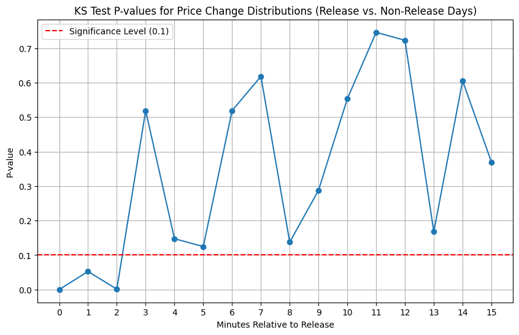

```python
#run this cell to produce the KS Test polot
from scipy import stats
price_change_bins_labels = heatmap_data_non_release.index
price_change_bins_midpoints = []
for label in price_change_bins_labels:
    lower_bound_str = label.split('%')[0]
    midpoint = float(lower_bound_str) / 100.0
    price_change_bins_midpoints.append(midpoint)
price_change_bins_midpoints = np.array(price_change_bins_midpoints)

minutes_to_test =pd.Series([float(m) for m in range(0, 16)])

ks_results = []

for minute in minutes_to_test:
    if minute not in heatmap_data_non_release.columns or minute not in heatmap_data_release.columns:
        print(f"Minute {minute} not found in both heatmaps. Skipping.")
        continue

    sample_non_release = []
    frequencies_non_release = heatmap_data_non_release[minute]
    for i, freq in enumerate(frequencies_non_release):
        sample_non_release.extend([price_change_bins_midpoints[i]] * freq)
    sample_non_release = np.array(sample_non_release)

    sample_release = []
    frequencies_release = heatmap_data_release[minute]
    for i, freq in enumerate(frequencies_release):
        sample_release.extend([price_change_bins_midpoints[i]] * freq)
    sample_release = np.array(sample_release)

    if sample_non_release.size > 0 and sample_release.size > 0:
        ks_statistic, p_value = stats.ks_2samp(sample_non_release, sample_release)
        ks_results.append({
            'Minute': float(minute),
            'KS Statistic': ks_statistic,
            'P-value': p_value
        })
    else:
        ks_results.append({
            'Minute': float(minute),
            'KS Statistic': np.nan,
            'P-value': np.nan,
            'Warning': 'One or both samples are empty, KS test not performed.'
        })

ks_results_df = pd.DataFrame(ks_results)

def create_ks_test_p_value_plot(ks_results_df):
    """
    Generates a line plot of KS test P-values for price change distributions.

    Args:
        ks_results_df: DataFrame containing 'Minute' and 'P-value' columns.

    Returns:
        matplotlib.figure.Figure: The generated plot figure.
    """
    line_plot_p_value_KS_test = plt.figure(figsize=(10, 6))
    plt.plot(ks_results_df['Minute'], ks_results_df['P-value'], marker='o', linestyle='-')
    plt.axhline(0.1, color='r', linestyle='--', label='Significance Level (0.1)')
    plt.title('KS Test P-values for Price Change Distributions (Release vs. Non-Release Days)')
    plt.xlabel('Minutes Relative to Release')
    plt.ylabel('P-value')
    plt.xticks(ks_results_df['Minute'])
    plt.legend()
    plt.grid(True)
    return line_plot_p_value_KS_test

line_plot_p_value_KS_test = create_ks_test_p_value_plot(ks_results_df)
```

# Algorithms

Having established that the initial two minutes of trading activity post-WPSR release represent the most relevant period for price movement, our focus shifted to predicting the percentage price change within this window using machine learning techniques.

Our group implemented and evaluated the following five regression algorithms:

- **Linear Regression** (Mia)
- **Random Forest Regression** (Quinn)
- **Extreme Gradient Boosting (XGBoost) Regression** (Evan)
- **Deep Neural Network (DNN)** (Terence)
- **K-Nearest Neighbors (KNN) Regression** (Samyak)

## Target Variable Justification: Percentage Price Change - Everyone

For this project, the target variable we aim to predict is the **percentage change in the WTI crude oil futures price, calculated two minutes after the WPSR release relative to the price at the moment of release.** This choice is deliberate and offers several key advantages for modeling financial time series, particularly in the context of event-driven price movements:

1. **Normalization and Comparability:**
   - Percentage change inherently normalizes the price movement by the prevailing price level. A $0.50 price move has a vastly different significance if crude oil is trading at $20/barrel versus $100/barrel. By using percentage change, we ensure that the target variable represents a relative magnitude of change, making predictions comparable across different time periods and varying absolute price levels. This is crucial as our dataset spans a considerable time, during which oil prices have fluctuated significantly.
2. **Stationarity Properties:**
   - Raw price series in finance are often non-stationary (e.g., they can exhibit trends, random walks, or unit roots). Non-stationary data can lead to spurious correlations and unreliable models. While not always perfectly stationary, log returns (which percentage changes closely approximate for small changes) tend to exhibit more stationary behavior than absolute price levels or even absolute price differences. This makes them more amenable to standard machine learning regression techniques.
3. **Addressing Heteroscedasticity (to some extent):**
   - Financial time series often exhibit volatility clustering (periods of high volatility followed by periods of low volatility). The variance of absolute price changes can be dependent on the price level (higher prices often mean larger absolute fluctuations). Percentage changes can help mitigate this effect, as the volatility of returns is often more stable.

```python
#pre processing
valid_releases = price_window_60min.loc[price_window_60min['Time_to_Release_Minutes'] == 2]
price_window_60min = price_window_60min[price_window_60min['Date'].isin(valid_releases['Date'])]
price_window_60min = price_window_60min[price_window_60min['Time_to_Release_Minutes'] <= 2]

def pivot_market_data(df, x_minutes_before, cols_to_pivot=None):
    """
    pivot into wide formate where minutes to release from [-x, 2] are kept as columns for each feature.
    """
    if cols_to_pivot is None:
        cols_to_pivot = ['Open', 'High', 'Low', 'Close', 'Volume']

    df_filtered = df[(df['Time_to_Release_Minutes'] <= 2) & (df['Time_to_Release_Minutes'] >= -x_minutes_before)].copy()

    df_long = df_filtered.melt(
        id_vars=['Datetime', 'Time_to_Release_Minutes', 'Release_Datetime'],
        value_vars=cols_to_pivot,
        var_name='Feature',
        value_name='Value'
    )
    df_long['Feature_min'] = df_long['Feature'] + '_t' + df_long['Time_to_Release_Minutes'].astype(int).astype(str)

    df_wide = df_long.pivot_table(
        index='Release_Datetime',
        columns='Feature_min',
        values='Value'
    ).reset_index()
    cols_to_drop = [col for col in df_wide.columns if 't2' in col and col != 'Close_t2']
    df_wide.drop(columns=cols_to_drop, inplace=True)
    return df_wide

df_wide = pivot_market_data(price_window_60min, x_minutes_before=60)

def get_time_offset(col_name):
    match = re.search(r't(-?\d+)$', col_name)
    if match: return int(match.group(1))
    return float('inf')

sorted_market_cols = sorted(df_wide.columns, key=get_time_offset)
df_wide = df_wide[sorted_market_cols]
df_wide.set_index('Release_Datetime', inplace=True)
df_wide['Price_Change'] = df_wide['Close_t2'] - df_wide['Open_t0']
#df_wide is now sorted

df_wide.reset_index(inplace=True)
df_wide['Release Date'] = df_wide['Release_Datetime'].dt.date
df_wide = df_wide.drop(columns=['Release_Datetime']).set_index('Release Date')

weekly_supply=pd.read_csv("InvestingcomEIA.csv")
weekly_supply['Release Date'] = pd.to_datetime(weekly_supply['Release Date'], format="%d-%b-%y").dt.strftime("%Y-%m-%d")
weekly_supply.set_index('Release Date', inplace=True)


weekly_prod=pd.read_csv("weekly_prod.csv", header=2)


weekly_import=pd.read_csv("net_import.csv")

df_wide = df_wide.sort_index()
df_wide.reset_index(inplace=True)
df_wide['Pct_Change'] = (df_wide['Close_t2'] - df_wide['Open_t0']) / df_wide['Open_t0'] * 100
weekly_supply = weekly_supply.sort_index()
weekly_supply.reset_index(inplace=True)

df_wide['Release Date'] = pd.to_datetime(df_wide['Release Date'])
weekly_supply['Release Date'] = pd.to_datetime(weekly_supply['Release Date'])
price_supply = pd.merge(df_wide, weekly_supply, how='left', on='Release Date')

weekly_prod['Date'] = pd.to_datetime(weekly_prod['Date'])
weekly_import['Date'] = pd.to_datetime(weekly_import['Date'])

prod_import = pd.merge(weekly_import, weekly_prod, how='left', on='Date').dropna()

mapping = pd.read_csv('FXmappings.csv')
split_data = mapping['Date'].str.split('(', expand=True)

mapping['ReleaseDate_str'] = split_data[0].str.strip()

mapping['end_date'] = split_data[1].str.rstrip(')').str.strip()

mapping['ReleaseDate'] = pd.to_datetime(mapping['ReleaseDate_str'], format='%m/%d/%Y')
mapping.drop(columns=['ReleaseDate_str', 'Date'], inplace=True)

release_year = mapping['ReleaseDate'].dt.year

full_end_date = mapping['end_date'] + ' ' + release_year.astype(str)

mapping['end_date'] = pd.to_datetime(full_end_date, format='%b %d %Y')

mapping['day_before'] = mapping['ReleaseDate'] - pd.Timedelta(days=1)

dow = mapping['day_before'].dt.dayofweek

days_to_subtract = (dow + 3) % 7

mapping['end_date'] = mapping['day_before'] - pd.to_timedelta(days_to_subtract, unit='D')

mapping.drop(columns=['day_before'], inplace=True)
mapping['end_date'] = pd.to_datetime(mapping['end_date'])
mapping = mapping.set_index('end_date').sort_index()
mapping.reset_index(inplace=True)

prod_import_mapped = pd.merge(mapping, prod_import, how='left', right_on='Date', left_on='end_date')
prod_import_mapped.drop(columns=['end_date', 'Date'], inplace=True)

full_data = pd.merge(price_supply, prod_import_mapped, how='left', left_on='Release Date', right_on='ReleaseDate')

full_data.drop(columns=['Time', 'ReleaseDate'], inplace=True)
full_data['Weekly Net Import'] = full_data['Weekly Net Import'] * 7
full_data['Weekly Production'] = full_data['Weekly U.S. Field Production of Crude Oil  (Thousand Barrels per Day)'] * 7

full_data = full_data.drop(columns=['Weekly U.S. Field Production of Crude Oil  (Thousand Barrels per Day)'])
full_data = full_data.dropna()


def convert_to_numeric(value):
    multiplier = 1_000_000
    numeric_part = value[:-1]

    try:
        return float(numeric_part) * multiplier
    except ValueError:
        return np.nan


for col in ['Actual', 'Forecast', 'Previous']:

    full_data[col] = full_data[col].apply(convert_to_numeric)

for col in ['Weekly Net Import', 'Weekly Production']:
    full_data[col] = full_data[col].apply(lambda x: x * 1000)
```

## Linear Regression (Mia Callahan)

### Design Justifications

The Linear Regression model, including its Lasso-regularized variant, was implemented with several key design decisions aimed at establishing a robust baseline, understanding linear relationships, and managing potential overfitting given the high dimensionality of the pre-release market data.

### 1. Choice of Linear Regression (and Lasso)

- **Decision**: Employ Linear Regression, subsequently augmented with Lasso (L1) regularization.
- **Justification**:
  - **Baseline Performance**: Linear Regression serves as a fundamental benchmark. Its performance provides a clear baseline against which more complex models (Random Forest, XGBoost, DNN) can be quantitatively compared. This helps in assessing whether the added complexity of other models translates into a significant improvement in predictive power for this specific financial prediction task.
  - **Interpretability**: Standard Linear Regression coefficients (especially after feature scaling) offer direct insights into the linear relationship (strength and direction) between each feature and the percentage price change. Lasso, by shrinking some coefficients to zero, further enhances interpretability by performing feature selection.
  - **Simplicity and Speed**: Linear models are computationally inexpensive and fast to train, making them ideal for initial data exploration and for establishing a quick performance reference.
  - **Identifying Linear Signals**: Despite the expectation of non-linearities in financial markets, this model helps to identify and quantify any strong, simple linear patterns that might be present in the feature set.

### 3. Feature Scaling

- **Decision**: Apply `StandardScaler` to the input features before training the Linear Regression and Lasso models.
- **Justification**:
  - **Equal Feature Contribution**: Linear Regression models, and particularly regularized versions like Lasso, are sensitive to the scale of input features. Features with larger numerical ranges can disproportionately influence the model's coefficient fitting process. `StandardScaler` normalizes features by removing the mean and scaling to unit variance. This ensures all features are on a comparable scale, allowing the model to learn their importance based on their relationship with the target, not their magnitude.
  - **Improved Regularization Performance**: For Lasso regression, which applies an L1 penalty to the coefficients, feature scaling is important for fair penalization. Without scaling, features with larger values would naturally have larger coefficients, leading to them being penalized more heavily, irrespective of their true predictive power. Scaling helps the regularization process to be more effective and stable.
  - **Numerical Stability**: Can improve the numerical stability and convergence speed of the optimization algorithms used in fitting the models.

### 5. Evaluation Metric

- **Decision**: Use Root Mean Squared Error (RMSE) to evaluate model performance on the test set.
- **Justification**:
  - **Standard Regression Metric**: RMSE is a widely accepted and standard metric for evaluating the accuracy of regression models.
  - **Penalizes Larger Errors More Heavily**: Due to the squaring of errors before averaging, RMSE gives a higher weight to larger errors. In financial predictions, large, unexpected errors can be particularly detrimental, making RMSE a suitable metric if the goal is to minimize such occurrences.

These design decisions collectively aim to build a well-regularized linear model that can serve as a solid baseline, provide insights into linear feature importance, and offer a fair comparison point for more advanced techniques applied in the project.

Running a linear regression acts as a baseline for our other models. We expect that the linear regression will not perform well, as the data likely has non-linear relationships. The bias-variance tradeoff likely will lead the linear regression to underfit the data as it is a very basic model. However, it will be interesting to see how it performs especially in comparison to the more complex models we will use later.

First, we plot each variable against our outcome variable to determine if linear relationships between the variable can be estimated. (Plotted last 20 features for readability follow comments to see every feature plotted)

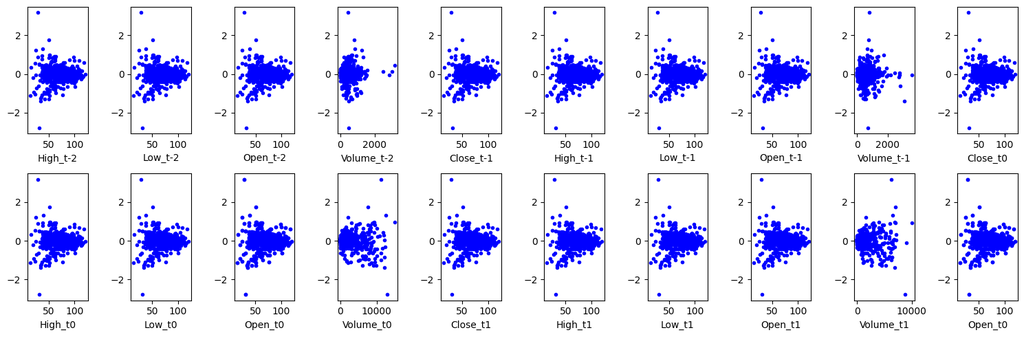

```python
#run to see feature linear plots

newy = df_wide['Pct_Change']
feature_cols = [col for col in df_wide.columns if '_t2' not in col and 't_1' not in col and 't_0' not in col and col not in ['Close_t2', 'Release_Datetime', 'Date', 'Pct_Change', 'Price_Change']] + ['Open_t0']
feature_cols = [col for col in feature_cols if col not in ['Unnamed: 0', 'Release Date']]
ncols = 10
nrows = 2 #-(-len(feature_cols) // ncols)
fig, axes = plt.subplots(nrows, ncols, figsize=(15, 2.5* nrows))
axes = axes.flatten()
X = df_wide[feature_cols]
y = df_wide['Close_t2']

import warnings
from sklearn.exceptions import ConvergenceWarning
warnings.filterwarnings('ignore', category=ConvergenceWarning)

for idx,col in enumerate(feature_cols[-20:]): # delete -20
    ax = axes[idx]
    xplot = X[col]
    ax.plot(xplot,newy, "b.")
    ax.set_xlabel(col, fontsize=10)
plt.tight_layout()
plt.show()
```

Unsurprisingly, this leads to a much less linear relationship between the data. While this will lead to worse performance of my model, the intended use of prediciton models is to be able to profit off of stock market changes,so this is a more useful metric.

```python
from sklearn.model_selection import TimeSeriesSplit
from sklearn.model_selection import train_test_split
from sklearn.preprocessing import StandardScaler
from sklearn.linear_model import LinearRegression
from sklearn.metrics import mean_squared_error


n_splits_outer = 3
tscv_outer = TimeSeriesSplit(n_splits=n_splits_outer)

for train_val_indices, test_indices in tscv_outer.split(X):
    pass

X_train_val_temp, y_train_val_temp = X.iloc[train_val_indices], newy.iloc[train_val_indices]
X_test, y_test = X.iloc[test_indices], newy.iloc[test_indices]

n_splits_inner = 3


tscv_inner = TimeSeriesSplit(n_splits=n_splits_inner)
for train_idx_inner, val_idx_inner in tscv_inner.split(X_train_val_temp):
    pass # Ensures we get the last set of indices
train_indices = train_idx_inner
val_indices = val_idx_inner


X_train, y_train = X_train_val_temp.iloc[train_indices], y_train_val_temp.iloc[train_indices]
X_val, y_val = X_train_val_temp.iloc[val_indices], y_train_val_temp.iloc[val_indices]

print("Data Split Sizes:")
print(f"Total samples: {len(X)}")
print(f"Training samples: {len(X_train)} (~{len(X_train)/len(X)*100:.1f}%)")
print(f"Validation samples: {len(X_val)} (~{len(X_val)/len(X)*100:.1f}%)")
print(f"Test samples: {len(X_test)} (~{len(X_test)/len(X)*100:.1f}%)")

scaler = StandardScaler()
X_train_scaled = scaler.fit_transform(X_train)
X_val_scaled = scaler.transform(X_val)
X_test_scaled = scaler.transform(X_test)

np.random.seed(42)
linmodel = LinearRegression()
linmodel.fit(X_train_scaled, y_train)

print(f"Intercept: {linmodel.intercept_}")
y_val_pred = linmodel.predict(X_val_scaled)
val_rmse = np.sqrt(mean_squared_error(y_val, y_val_pred))
print(f"Validation RMSE: {val_rmse:.4f}")

# Predictions on the test set
y_test_pred = linmodel.predict(X_test_scaled)
test_rmse = np.sqrt(mean_squared_error(y_test, y_test_pred))
print(f"Test RMSE: {test_rmse:.4f}")
```

```
Data Split Sizes:
Total samples: 731
Training samples: 412 (~56.4%)
Validation samples: 137 (~18.7%)
Test samples: 182 (~24.9%)
Intercept: -0.02721175775627985
Validation RMSE: 0.3799
Test RMSE: 0.5521
```

Because there are so many features it is likely that the linear reegression will overfit because it will try to fit all of the features, even if they are not relevant. After seeing performance, we will reduce the number of features to see if this improves out of sample performance.

The RMSE of the model on the test set is .55, which is much better than I expected. This could change for a larger data sample. To try to prevent any overfitting from the large number of features, I will now use lasso to select the most useful features. First I will cross validate to find the ideal alpha.

```python
from sklearn.linear_model import Lasso
mses = []
best_mse = float('inf')
best_alpha = None
alphas = np.logspace(-10, 0, 100)
for alpha in alphas:
    lasso = Lasso(alpha=alpha,  random_state=42)
    lasso.fit(X_train_scaled, y_train)
    mse = mean_squared_error(y_val, lasso.predict(X_val_scaled))
    mses.append(mse)
    if mse < best_mse:
        best_mse = mse
        best_alpha = alpha
print(f"Best alpha: {best_alpha}")
```

```
Best alpha: 0.09770099572992247
```

```python
lasso_best = Lasso(alpha=best_alpha, random_state=42)
lasso_best.fit(X_train_scaled, y_train)
# see how it performs on out of sample data
y_hat_lasso = lasso_best.predict(X_test_scaled)
error_lasso = np.sqrt(np.mean((y_hat_lasso - y_test) ** 2))
print(f"RMSE on test set with Lasso: {error_lasso:.2f}")
```

```
RMSE on test set with Lasso: 0.27
```

## Random Forest (Quinn Kelly)

### Why Random Forest Was Chosen for Implementation:

Random Forest is a robust and widely used ensemble learning method, and its selection for predicting financial metrics (like price changes based on news sentiment) can be justified for several key reasons:

1. **Ability to Capture Non-Linear Relationships:**
   - Financial markets are notoriously complex, and the relationship between input features (e.g., news sentiment, technical indicators, economic data) and the target variable (e.g., price change) is rarely linear. Random Forest, being an ensemble of decision trees, is inherently capable of modeling complex, non-linear interactions between features without requiring explicit transformation or specification of these interactions beforehand.
2. **Robustness to Overfitting (Compared to Single Decision Trees):**
   - While individual decision trees can easily overfit the training data, Random Forest mitigates this risk through two main mechanisms:
     - **Bagging (Bootstrap Aggregating):** Each tree in the forest is trained on a random bootstrap sample of the training data.
     - **Feature Randomness:** At each split in a tree, only a random subset of features is considered.
   - This combination creates diverse trees, and averaging their predictions tends to reduce variance and lead to better generalization on unseen data. The use of `ccp_alpha` for pruning further helps control complexity and prevent overfitting.
3. **Good Performance with Less Hyperparameter Tuning (Relatively):**
   - Compared to some other advanced models (like Support Vector Machines or Neural Networks), Random Forests can often achieve good performance with less extensive hyperparameter tuning. They are often a strong "out-of-the-box" performer, making them a good choice for establishing a solid baseline or even as a primary model.
4. **Handling of Different Feature Types and Scales:**
   - Random Forests can handle numerical features directly without requiring extensive preprocessing like feature scaling (though scaling can sometimes still be beneficial for other parts of a pipeline or for consistency). This simplifies the preprocessing pipeline.
5. **Implicit Feature Importance Estimation:**
   - Random Forests provide a natural way to estimate the importance of each feature in making predictions (e.g., by measuring how much each feature contributes to reducing impurity across all trees). In a financial context, understanding which factors (e.g., sentiment from specific news categories, particular economic indicators) are most influential can be as valuable as the prediction itself.
6. **Robustness to Outliers and Noisy Data:**
   - Financial data is often noisy and can contain outliers. The ensemble nature of Random Forest, where predictions are averaged across many trees, makes the model more robust to the influence of individual outliers or noise points in the training data compared to models that might be heavily skewed by such points.
7. **Good Choice as a Benchmark or Comparison Model:**
   - Even if more complex models like Gradient Boosting (XGBoost, LightGBM) or Neural Networks are also being considered, Random Forest serves as an excellent benchmark. Its performance can provide a strong baseline against which other, potentially more complex or harder-to-tune, models can be compared. It represents a powerful, yet relatively understandable, class of non-linear models.

### Design Justifications:

### 1. Hyperparameters Grid and Tuning Strategy

- **Decision - `'n_estimators_list': [200, 400, 600]`, `'ccp_alpha_list': [10**-2, 10**-3, 10**-5, 10**-7]`**:
  - **`n_estimators`**: This parameter defines the number of trees in the forest. A larger number of trees generally improves the model's performance and stability by reducing variance, but at an increased computational cost. The list `[200, 400, 600]` explores a range of forest sizes to balance predictive power and efficiency.
  - **`ccp_alpha` (Minimal Cost-Complexity Pruning)**: This parameter controls the complexity of the individual trees within the forest. Non-negative values of `ccp_alpha` act as a threshold for pruning; trees (or subtrees) that do not offer sufficient improvement in terms of impurity reduction (scaled by `ccp_alpha`) are pruned. Larger `ccp_alpha` values lead to more aggressive pruning and simpler trees, which can help prevent overfitting. The selected range `[10**-2, 10**-3, 10**-5, 10**-7]` allows for testing various degrees of pruning, from relatively strong to very mild.

### 2. Time Series Cross-Validation and Data Splitting

- **Decision - `tscv = TimeSeriesSplit(n_splits=n_split)` (e.g., `n_split=3`)**:
  - **Justification**: Standard k-fold cross-validation is inappropriate for time-series data because it can lead to lookahead bias (training on future data to predict the past). `TimeSeriesSplit` ensures that the training set always precedes the validation/test set. In each split, the training set grows, and the test set is the next chronological block of data, mimicking how a model would be deployed in real-time. `n_split=3` creates 3 such chronological train/test splits.

```python
from sklearn.model_selection import TimeSeriesSplit
from sklearn.ensemble import RandomForestRegressor
import matplotlib.pyplot as plt
import numpy as np
from sklearn.metrics import mean_squared_error


def time_series_valid_test(X, y, n_split, valid_or_test, n_estimators_list, ccp_alpha_list, optimal_par=None):
    np.random.seed(42)
    tscv = TimeSeriesSplit(n_splits=n_split)
    rf_rmse = []
    rmseSmall = []
    param_combinations = []  # param combo storagae
    i = 0  # fold counter
    for train_index, test_index in tscv.split(X):
        i += 1
        # Break test set into 50% validation set, 50% test set
        break_test_ind = int(test_index[0] + 0.5*(test_index[-1]-test_index[0]))
        valid_index = np.array(list(range(test_index[0],break_test_ind)))
        test_index = np.array(list(range(break_test_ind,test_index[-1])))

        # Split data into training, validation, and test sets
        X_train, X_valid, X_test = X.iloc[train_index], X.iloc[valid_index], X.iloc[test_index]
        y_train, y_valid, y_test = y.iloc[train_index], y.iloc[valid_index], y.iloc[test_index]

        # Tuning
        if valid_or_test == "valid":
            rf_rmse_fold = []
            for n_estimators in n_estimators_list:
                for ccp_alpha in ccp_alpha_list:
                    model_rf = RandomForestRegressor(random_state=42,
                                                     n_estimators=n_estimators,
                                                     ccp_alpha=ccp_alpha,
                                                     n_jobs=-1)


                    X_train_sample = X_train.sample(frac=0.1, random_state=42)
                    y_train_sample = y_train.loc[X_train_sample.index]

                    model_rf.fit(X_train_sample, y_train_sample.to_numpy())


                    y_val_rf = model_rf.predict(X_valid)
                    fold_rmse = np.sqrt(mean_squared_error(y_valid, y_val_rf))
                    rf_rmse_fold.append(fold_rmse)
                    param_combinations.append((n_estimators, ccp_alpha))

            rf_rmse.append(np.mean(rf_rmse_fold))

        if valid_or_test == "test":
            model_rf = RandomForestRegressor(random_state=42,
                                             n_estimators=optimal_par[0],
                                             ccp_alpha=optimal_par[1],
                                             n_jobs=-1)
            model_rf.fit(X_train, y_train.to_numpy())
            y_test_rf = model_rf.predict(X_test)
            test_rmse = np.sqrt(mean_squared_error(y_test, y_test_rf))
            rf_rmse.append(test_rmse)

            # Plot the prediction for the last CV fold
            if i == n_split:
                plt.plot(range(len(X_test)), y_test_rf, label="Prediction")
                plt.plot(range(len(X_test)), y_test, label="True Value")
                plt.legend(loc="upper left")
                plt.show()

    # Return results
    if valid_or_test == "valid":
        min_rmse_idx = np.argmin(rf_rmse)  # Find index of lowest RMSE
        optimal_params = param_combinations[min_rmse_idx]  # Retrieve corresponding parameters
        return rf_rmse, optimal_params
    if valid_or_test == "test":
        rf_rmse = np.mean(rf_rmse)
        rmseSmallAns = np.mean(rmseSmall)
        return y_test_rf, y_test
```

```python
# Hyperparameter combinations
n_estimators_list = [200, 400, 600]
ccp_alpha_list = [10**-2, 10**-3, 10**-5, 10**-7]


rf_rmse, optimal_params = time_series_valid_test(X, newy, n_split = 3, valid_or_test = "valid",
                                                 n_estimators_list = n_estimators_list,
                                                 ccp_alpha_list = ccp_alpha_list)
print("Optimal Parameters:", optimal_params)
print("Validation RMSEs (Validation):", rf_rmse)
```

```
Optimal Parameters: (200, 1e-05)
Validation RMSEs (Validation): [0.7044190597545149, 0.336229695292928, 0.28911024341411684]
```

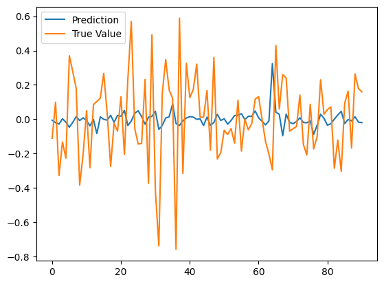

```
RMSE on test set at final fold: 0.2523032045361738
```

```python
y_test_rf, y_test_actual = time_series_valid_test(X, newy, n_split = 3, valid_or_test = "test",
                                            n_estimators_list = n_estimators_list,
                                            ccp_alpha_list = ccp_alpha_list,
                                            optimal_par = optimal_params)

print("RMSE on test set at final fold:", np.sqrt(mean_squared_error(y_test_rf, y_test_actual)))
```

## Extreme Gradient Boost (XGBoost) Regression (Evan Sun)

#### Reasons I chose to implement XGBoost:

1. **Superior Predictive Performance and Robustness:**
   - XGBoost is a gradient boosting algorithm renowned for its high predictive accuracy. It often outperforms other algorithms in machine learning competitions and real-world applications (I've lost too many kaggle competitions to XGBoost), including finance.
   - The ensemble nature of XGBoost, where multiple decision trees are built sequentially with each new tree correcting the errors of the previous ones, leads to a robust model that is less prone to individual tree weaknesses.
2. **Effective Handling of Non-Linearity and Feature Interactions:**
   - Financial markets, and specifically price responses to news events like the EIA WPSR, rarely exhibit simple linear relationships. Price changes can be influenced by a complex interplay of various factors (e.g., the magnitude of the surprise in the report, prevailing market sentiment, existing inventory levels, recent price trends).
   - XGBoost, being a tree-based model, excels at capturing these non-linear relationships and high-order interactions between features without requiring explicit feature engineering for these interactions (e.g., creating polynomial terms).
3. **Built-in Regularization to Prevent Overfitting:**
   - Financial data is notoriously noisy, and overfitting is a significant risk. XGBoost incorporates both L1 (Lasso) and L2 (Ridge) regularization terms in its objective function.
   - This regularization helps to penalize model complexity, shrink less important feature weights, and thus improve the model's ability to generalize to unseen data – crucial for predicting future price movements after a WPSR release. Your hyperparameter grid explicitly tunes `reg_alpha` (L1) and `reg_lambda` (L2), leveraging this strength.
4. **Computational Efficiency and Scalability:**
   - XGBoost is designed for speed and efficiency. It implements parallel processing for tree construction and cache-aware access patterns.

```python
#create training and test split
column_names = []
variable_names = ['Open', 'High', 'Low', 'Close', 'Volume']
for var_name in variable_names:
    for min in range(60):
        column_names.append(f'{var_name}_t{min-60}')

column_names.append('Open_t0')

new_cols = ['Actual', 'Forecast', 'Previous', 'Weekly Net Import','Weekly Production']
for col_name in new_cols:
    column_names.append(col_name)

n_total_events = len(full_data)
test_set_size_ratio = 0.2

test_set_split_index = int(n_total_events * (1 - test_set_size_ratio))

# Data for hyperparameter tuning and training the final model
X_tuning_full = full_data.iloc[:test_set_split_index][column_names]
y_tuning_full = full_data.iloc[:test_set_split_index]['Pct_Change']

# Final hold-out test set (never seen during tuning)
X_test_holdout = full_data.iloc[test_set_split_index:][column_names]
y_test_holdout = full_data.iloc[test_set_split_index:]['Pct_Change']

print(f"Full dataset size: {len(df_wide)}")
print(f"Tuning dataset size: {len(X_tuning_full)}")
print(f"Hold-out test dataset size: {len(X_test_holdout)}")
```

```
Full dataset size: 731
Tuning dataset size: 586
Hold-out test dataset size: 147
```

### Design Justifications:

Some of the design decisions made might not be conventional and thus can be explained as follows:

### 1. Hyperparameters Grid

- **Decision - `'n_estimators': [1000]`**: I chose the max value here since I'm using early stopping so I can let early stopping determine the optimal number of trees dynamically for each hyperparameter combination and fold. The `actual_n_estimators` is then recorded and averaged.

### 2. Time Series Cross-Validation

- **Decision - `'tscv = TimeSeriesSplit(n_splits=3)`**: I'm using a time series split because for financial time series data (like price changes), it's crucial that the validation set always comes *after* the training set to prevent lookahead bias and realistically simulate how the model would be used in practice (training on past data to predict future data).

### 3. Early Stopping

- **Decision - `'early_stopping_rounds_val = 10`**: I chose to use early stopping for 2 reasons:
  - Prevents the model from fitting the training data too closely and losing generalization ability.
  - saves computation time by not necessarily training for the full `n_estimators` if optimal performance is achieved earlier.

### 4. Sample Weighting

```python
#train and tune model
hyperparam_grid = {
    'n_estimators': [1000],
    'learning_rate': [0.01, 0.05, 0.1],
    'max_depth': [6, 7, 8],
    'subsample': [0.85, 0.9, 0.95],
    'colsample_bytree': [0.85, 0.9, 0.95],
    'reg_alpha': [0.1, 0.3, 0.5],
    'reg_lambda': [3, 4, 5],
}

param_list = list(ParameterGrid(hyperparam_grid))


tscv = TimeSeriesSplit(n_splits=3)
results = []
early_stopping_rounds_val = 10


epsilon = 1e-6
weights_tuning_full = np.abs(y_tuning_full) + epsilon
weights_test_holdout = np.abs(y_test_holdout) + epsilon


print(f"Starting hyperparameter tuning with TimeSeriesSplit. Total combinations: {len(param_list)}")
for fold, (train_index, val_index) in enumerate(tscv.split(X_tuning_full)):
    print(f"\nFold {fold+1}/{tscv.get_n_splits()}")
    X_train_fold, y_train_fold = X_tuning_full.iloc[train_index], y_tuning_full.iloc[train_index]
    X_val_fold, y_val_fold = X_tuning_full.iloc[val_index], y_tuning_full.iloc[val_index]
    weights_train_fold = weights_tuning_full.iloc[train_index]
    weights_val_fold = weights_tuning_full.iloc[val_index]

    print(f"  Training on {len(X_train_fold)} instances, validating on {len(X_val_fold)} instances.")


    for i, params in enumerate(param_list):
        if (i + 1) % 10 == 0 or i == 0 or i == len(param_list) -1 :
             print(f"    Combination {i+1}/{len(param_list)}: {params}")

        model = xgb.XGBRegressor(
            objective='reg:squarederror',
            random_state=42,
            early_stopping_rounds=early_stopping_rounds_val,
            n_jobs=-1,
            **params
        )

        model.fit(X_train_fold, y_train_fold,
                  sample_weight=weights_train_fold,
                  eval_set=[(X_val_fold, y_val_fold)],
                  sample_weight_eval_set=[weights_val_fold],
                  verbose=False)

        y_pred_val = model.predict(X_val_fold)
        val_rmse = np.sqrt(mean_squared_error(y_val_fold, y_pred_val, sample_weight=weights_val_fold))

        result_entry = params.copy()
        result_entry['fold'] = fold + 1
        result_entry['val_rmse'] = val_rmse
        result_entry['actual_n_estimators'] = model.best_iteration
        results.append(result_entry)

results_df = pd.DataFrame(results)

grouping_cols = [col for col in hyperparam_grid.keys() if col != 'n_estimators']
average_metrics_across_folds = results_df.groupby(grouping_cols).agg(
    avg_val_rmse=('val_rmse', 'mean'),
    avg_actual_n_estimators=('actual_n_estimators', 'mean')
).reset_index()


best_params_row = average_metrics_across_folds.loc[average_metrics_across_folds['avg_val_rmse'].idxmin()]

best_hyperparams = best_params_row.to_dict()
best_hyperparams['max_depth'] = int(best_hyperparams.get('max_depth'))
best_avg_rmse = best_hyperparams.pop('avg_val_rmse')
best_actual_n_estimators = int(round(best_hyperparams.pop('avg_actual_n_estimators')))


print("\nBest hyperparameters found via TimeSeriesSplit CV:")
for param_name, param_val in best_hyperparams.items():
    print(f"  {param_name}: {param_val}")
print(f"  (Best actual n_estimators found by early stopping, averaged): {best_actual_n_estimators}")
print(f"  Average Validation RMSE across folds: {best_avg_rmse:.4f}")
```

```
Starting hyperparameter tuning with TimeSeriesSplit. Total combinations: 729

Fold 1/3
  Training on 148 instances, validating on 146 instances.
    Combination 1/729: {'colsample_bytree': 0.85, 'learning_rate': 0.01, 'max_depth': 6, 'n_estimators': 1000, 'reg_alpha': 0.1, 'reg_lambda': 3, 'subsample': 0.85}
    Combination 10/729: {'colsample_bytree': 0.85, 'learning_rate': 0.01, 'max_depth': 6, 'n_estimators': 1000, 'reg_alpha': 0.3, 'reg_lambda': 3, 'subsample': 0.85}
    Combination 20/729: {'colsample_bytree': 0.85, 'learning_rate': 0.01, 'max_depth': 6, 'n_estimators': 1000, 'reg_alpha': 0.5, 'reg_lambda': 3, 'subsample': 0.9}
    Combination 30/729: {'colsample_bytree': 0.85, 'learning_rate': 0.01, 'max_depth': 7, 'n_estimators': 1000, 'reg_alpha': 0.1, 'reg_lambda': 3, 'subsample': 0.95}
    Combination 40/729: {'colsample_bytree': 0.85, 'learning_rate': 0.01, 'max_depth': 7, 'n_estimators': 1000, 'reg_alpha': 0.3, 'reg_lambda': 4, 'subsample': 0.85}
    Combination 50/729: {'colsample_bytree': 0.85, 'learning_rate': 0.01, 'max_depth': 7, 'n_estimators': 1000, 'reg_alpha': 0.5, 'reg_lambda': 4, 'subsample': 0.9}
    Combination 60/729: {'colsample_bytree': 0.85, 'learning_rate': 0.01, 'max_depth': 8, 'n_estimators': 1000, 'reg_alpha': 0.1, 'reg_lambda': 4, 'subsample': 0.95}
    Combination 70/729: {'colsample_bytree': 0.85, 'learning_rate': 0.01, 'max_depth': 8, 'n_estimators': 1000, 'reg_alpha': 0.3, 'reg_lambda': 5, 'subsample': 0.85}
    Combination 80/729: {'colsample_bytree': 0.85, 'learning_rate': 0.01, 'max_depth': 8, 'n_estimators': 1000, 'reg_alpha': 0.5, 'reg_lambda': 5, 'subsample': 0.9}
    Combination 90/729: {'colsample_bytree': 0.85, 'learning_rate': 0.05, 'max_depth': 6, 'n_estimators': 1000, 'reg_alpha': 0.1, 'reg_lambda': 5, 'subsample': 0.95}
    Combination 100/729: {'colsample_bytree': 0.85, 'learning_rate': 0.05, 'max_depth': 6, 'n_estimators': 1000, 'reg_alpha': 0.5, 'reg_lambda': 3, 'subsample': 0.85}
    Combination 110/729: {'colsample_bytree': 0.85, 'learning_rate': 0.05, 'max_depth': 7, 'n_estimators': 1000, 'reg_alpha': 0.1, 'reg_lambda': 3, 'subsample': 0.9}
    Combination 120/729: {'colsample_bytree': 0.85, 'learning_rate': 0.05, 'max_depth': 7, 'n_estimators': 1000, 'reg_alpha': 0.3, 'reg_lambda': 3, 'subsample': 0.95}
    Combination 130/729: {'colsample_bytree': 0.85, 'learning_rate': 0.05, 'max_depth': 7, 'n_estimators': 1000, 'reg_alpha': 0.5, 'reg_lambda': 4, 'subsample': 0.85}
    Combination 140/729: {'colsample_bytree': 0.85, 'learning_rate': 0.05, 'max_depth': 8, 'n_estimators': 1000, 'reg_alpha': 0.1, 'reg_lambda': 4, 'subsample': 0.9}
    Combination 150/729: {'colsample_bytree': 0.85, 'learning_rate': 0.05, 'max_depth': 8, 'n_estimators': 1000, 'reg_alpha': 0.3, 'reg_lambda': 4, 'subsample': 0.95}
    Combination 160/729: {'colsample_bytree': 0.85, 'learning_rate': 0.05, 'max_depth': 8, 'n_estimators': 1000, 'reg_alpha': 0.5, 'reg_lambda': 5, 'subsample': 0.85}
    Combination 170/729: {'colsample_bytree': 0.85, 'learning_rate': 0.1, 'max_depth': 6, 'n_estimators': 1000, 'reg_alpha': 0.1, 'reg_lambda': 5, 'subsample': 0.9}
    Combination 180/729: {'colsample_bytree': 0.85, 'learning_rate': 0.1, 'max_depth': 6, 'n_estimators': 1000, 'reg_alpha': 0.3, 'reg_lambda': 5, 'subsample': 0.95}
    Combination 190/729: {'colsample_bytree': 0.85, 'learning_rate': 0.1, 'max_depth': 7, 'n_estimators': 1000, 'reg_alpha': 0.1, 'reg_lambda': 3, 'subsample': 0.85}
    Combination 200/729: {'colsample_bytree': 0.85, 'learning_rate': 0.1, 'max_depth': 7, 'n_estimators': 1000, 'reg_alpha': 0.3, 'reg_lambda': 3, 'subsample': 0.9}
    Combination 210/729: {'colsample_bytree': 0.85, 'learning_rate': 0.1, 'max_depth': 7, 'n_estimators': 1000, 'reg_alpha': 0.5, 'reg_lambda': 3, 'subsample': 0.95}
```

[output cut: 216 more lines]

```python
#evaluate model on test set
print("\n--- Training Final Model with Best Hyperparameters ---")
params_for_final_model = best_hyperparams.copy()

final_model = xgb.XGBRegressor(
    objective='reg:squarederror',
    random_state=42,
    n_jobs=-1,
    n_estimators=best_actual_n_estimators,
    **params_for_final_model
)

print(f"Training final model on {len(X_tuning_full)} instances.")
final_model.fit(X_tuning_full, y_tuning_full,
                sample_weight=weights_tuning_full,
                verbose=False)

print("\n--- Evaluating Final Model on Hold-Out Test Set ---")
y_pred_test_holdout = final_model.predict(X_test_holdout)

test_rmse = np.sqrt(mean_squared_error(y_test_holdout, y_pred_test_holdout,
                                       sample_weight=weights_test_holdout))

print(f"Final Model Performance on Hold-Out Test Set:")
print(f"  Test RMSE: {test_rmse:.6f}")

baseline_pred_zero = np.zeros_like(y_test_holdout)
baseline_rmse_zero = np.sqrt(mean_squared_error(y_test_holdout, baseline_pred_zero,
                                                 sample_weight=weights_test_holdout))

print(f"\nBaseline Model (Predict Zero Change) Performance on Hold-Out Test Set:")
print(f"  Baseline RMSE: {baseline_rmse_zero:.6f}")

try:
    feature_importances = final_model.feature_importances_
    importance_df = pd.DataFrame({'feature': X_tuning_full.columns, 'importance': feature_importances})
    importance_df = importance_df.sort_values(by='importance', ascending=False)
    print("\nTop 10 Feature Importances from Final Model:")
    print(importance_df.head(10))
except Exception as e:
    print(f"Could not retrieve feature importances: {e}")
```

```
--- Training Final Model with Best Hyperparameters ---
Training final model on 586 instances.

--- Evaluating Final Model on Hold-Out Test Set ---
Final Model Performance on Hold-Out Test Set:
  Test RMSE: 0.393174

Baseline Model (Predict Zero Change) Performance on Hold-Out Test Set:
  Baseline RMSE: 0.402660

Top 10 Feature Importances from Final Model:
         feature  importance
261  Volume_t-39    0.206890
248  Volume_t-52    0.066634
0      Open_t-60    0.059081
295   Volume_t-5    0.055731
251  Volume_t-49    0.053814
271  Volume_t-29    0.051934
297   Volume_t-3    0.035970
4      Open_t-56    0.034913
301       Actual    0.032565
244  Volume_t-56    0.029560
```

**Evaluation of Results:**

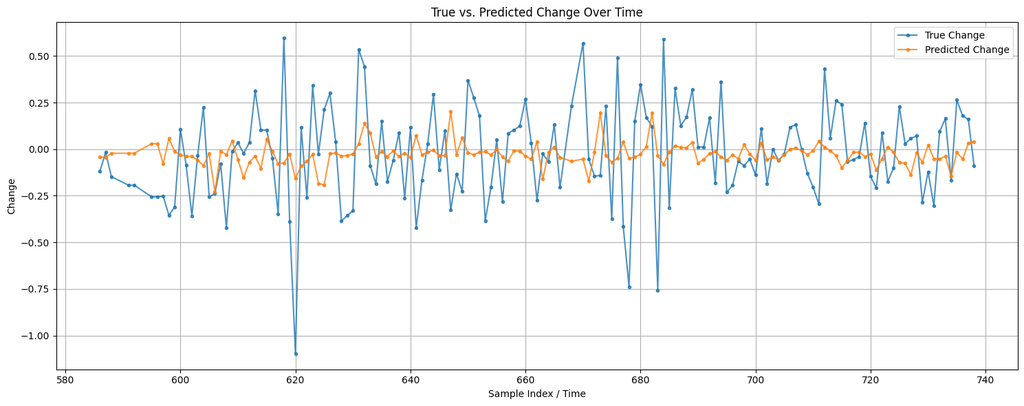

```python
plt.figure(figsize=(15, 6))
time_indices = X_test_holdout.index

true_changes_flat = y_test_holdout.flatten() if hasattr(y_test_holdout, 'flatten') else y_test_holdout
predicted_changes_flat = y_pred_test_holdout.flatten() if hasattr(y_pred_test_holdout, 'flatten') else y_pred_test_holdout
comparison_df = pd.DataFrame({
    'True Change': true_changes_flat,
    'Predicted Change': predicted_changes_flat
})
plt.plot(time_indices, comparison_df['True Change'], label='True Change', marker='.', linestyle='-', alpha=0.8)
plt.plot(time_indices, comparison_df['Predicted Change'], label='Predicted Change', marker='.', linestyle='-', alpha=0.8)
plt.xlabel("Sample Index / Time")
plt.ylabel("Change")
plt.title(f"True vs. Predicted Change Over Time")
plt.legend()
plt.grid(True)
plt.tight_layout() # Adjust layout to make room for labels
plt.show()
```

## Deep Neural Network (Terence Chiu)

Overview

This model implements a Deep Neural Network (DNN) to predict percentage changes in price following economic data releases. The model takes into account both historical price data and weekly economic indicators to make predictions.

Model Architecture

- **Input Layer**: 7 features
  - 4 price-related features: Close prices at t-60, t-40, t-20, and Open price at t0
  - 3 weekly economic indicators: Weekly Production, Weekly Net Import, and Actual Supply
- **Hidden Layers**:
  - First layer: 32 neurons with ReLU activation
  - Second layer: 8 neurons with ReLU activation
  - Dropout rate of 0.2 after each hidden layer
- **Output Layer**: Single neuron for percentage change prediction
- **Learning Rate**: 0.000187 (optimized through hyperparameter tuning, check terenceTuningModel.py)

Data Processing

- **Feature Scaling**: All input features are standardized using StandardScaler
- **Target Variable**: Percentage change in price 2 minutes after release
- **Train-Test Split**: 80-20 time-based split to maintain temporal order
- **Sample Weighting**: Implemented to give more importance to larger price movements

Training Process

- **Optimizer**: Adam optimizer - Adapts learning rates for each parameter individually
- **Loss Function**: Mean Squared Error (MSE) - - Aligns with our goal of minimizing prediction errors since it penalizes larger errors
- **Metrics**:
  - Custom RMSE metric - matches evaluation metric used in financial analysis, and more sensisitive to outliers than MAE
  - Mean Absolute Error (MAE) - robost for extreme data
- **Early Stopping**: - Prevent overfitting
  - Monitors validation RMSE
  - Patience of 10 epochs
  - Restores best weights

Model Performance

- **Evaluation Metric**: Weighted RMSE
- **Baseline Comparison**: Model performance is compared against a baseline of predicting zero change
- **Feature Importance**: Analyzed using gradient-based importance scores to understand feature contributions

Key Innovations

1. **Sample Weighting**: Implementation of sample weights to handle the imbalance between small and large price movements
2. **Custom RMSE Metric**: Development of a custom RMSE metric for better model evaluation
3. **Feature Importance Analysis**: Gradient-based analysis to understand feature contributions
4. **Time-Based Split**: Maintaining temporal order in train-test split to prevent look-ahead bias

Model Limitations

1. Relies on only four prices within 60 minutes prior to weekly report release
2. Does not look at whole market fluctuations
3. Performance depends on the quality and timeliness of the economic data releases

Future Improvements

1. Experiment with different network architectures, such as LSTM, CNN?
2. Incorporate additional features or market indicators
3. Implement ensemble methods with other models
4. Explore different loss functions for better handling of extreme price movements

Data Retrieval

```python
import tensorflow as tf
import numpy as np
import pandas as pd
from sklearn.preprocessing import StandardScaler
from sklearn.metrics import mean_squared_error

df = pd.read_csv("full_data.csv")

feature_cols = [col for col in df.columns if 'Close_t-60'  in col or 'Close_t-40' in col or 'Close_t-20' in col or col == 'Release Date' or col == 'Actual' or col == 'Weekly Net Import' or col == 'Weekly Production' or col == 'Open_t0']

X_temp = df[feature_cols]
y_temp = (df['Close_t2'] - df['Close_t0'])/df['Close_t0']

prod_weekly = X_temp[['Release Date', 'Weekly Production']]
net_import_weekly = X_temp[['Release Date', 'Weekly Net Import']]
supply_weekly = X_temp[['Release Date', 'Actual']]
price_wide = X_temp[['Release Date', 'Close_t-60', 'Close_t-40', 'Close_t-20', 'Open_t0']]
```

Data Scaling - for price features, weekly features, and target price feature

```python
price_scaler = StandardScaler()
target_scaler = StandardScaler()

price_features = price_wide[['Close_t-60', 'Close_t-40', 'Close_t-20', 'Open_t0']]

# Scale the price features in the dataframe
for col in ['Close_t-60', 'Close_t-40', 'Close_t-20', 'Open_t0']:
    price_features[col] = price_scaler.fit_transform(price_wide[col].values.reshape(-1, 1)).flatten()

# Scale the target values in the dataframe
y_temp = target_scaler.fit_transform(y_temp.values.reshape(-1, 1)).flatten()

#Scaler for weekly data
weekly_scaler = StandardScaler()

weekly_production_scaled = weekly_scaler.fit_transform(prod_weekly['Weekly Production'].values.reshape(-1, 1)).flatten()
weekly_import_scaled = weekly_scaler.fit_transform(net_import_weekly['Weekly Net Import'].values.reshape(-1, 1)).flatten()
weekly_supply_scaled = weekly_scaler.fit_transform(supply_weekly['Actual'].values.reshape(-1, 1)).flatten()

X = []
y = []

for idx, row in price_features.iterrows():
    # Target: price of future 2 minutes after release (already scaled)
    target_price = y_temp[idx]


    production_value = weekly_production_scaled[idx]
    import_value = weekly_import_scaled[idx]
    supply_value = weekly_supply_scaled[idx]

    row_data = [price_features['Close_t-60'].values[idx],price_features['Close_t-40'].values[idx],price_features['Close_t-20'].values[idx],price_features['Open_t0'].values[idx],production_value,import_value,supply_value]
    X.append(row_data)
    y.append(target_price)

X = np.array(X)
y = np.array(y)
```

[output not shown]

Importing Model from terenceModel.py. Model decision/architecture decided from terenceTuneModel using keras_tuner. Best hyperparameters found from tuning

```
1. Best configuration:
2. 2 layers: [32 units, 0.2 dropout], [8 units, 0.2 dropout]
3. Learning rate: 0.000187
```

```python
from terenceModel import DNN
from terenceTrainModel import plot_predictions

# Time-based 80/20 split
n = len(X)
split_idx = int(n * 0.8)
X_train, X_test = X[:split_idx], X[split_idx:]
y_train, y_test = y[:split_idx], y[split_idx:]
```

We applied sample weights in training of model, and the calculation of RMSE, as (close to) 0 percent change was something that was likely to occur. This model will be shown to be outperforming the baseline model.

```python
# Compute sample weights for training and test sets
epsilon = 1e-6
sample_weights_train = np.abs(y_train) + epsilon
sample_weights_test = np.abs(y_test) + epsilon

model = DNN()

# Train model with sample weights
trained_model, _ = model.train(X_train, y_train, sample_weight=sample_weights_train)

# Predict on test set
y_pred = trained_model.predict(X_test).flatten()

# Weighted RMSE for test set
weighted_test_rmse = np.sqrt(mean_squared_error(y_test, y_pred, sample_weight=sample_weights_test))
print(f"Weighted Test RMSE: {weighted_test_rmse:.4f}")
```

```
Weighted Test RMSE: 1.5660
```

```
Baseline (Zero Prediction) Weighted RMSE: 1.5964
Model outperforms baseline (predicting zero change).
Test RMSE: 1.1196
```

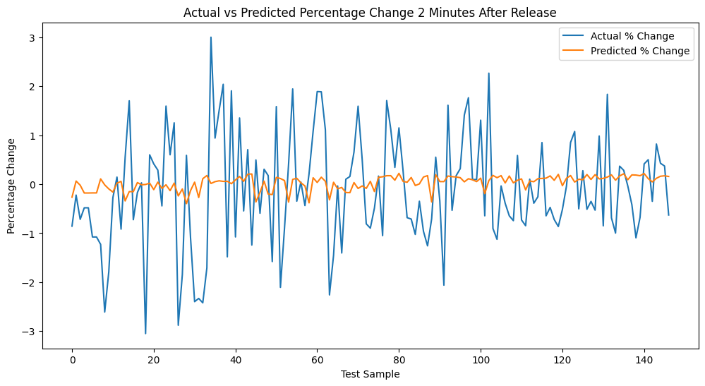

```python
baseline_pred_zero = np.zeros_like(y_test)
baseline_rmse_zero = np.sqrt(mean_squared_error(y_test, baseline_pred_zero, sample_weight=sample_weights_test))
print(f"Baseline (Zero Prediction) Weighted RMSE: {baseline_rmse_zero:.4f}")

if weighted_test_rmse < baseline_rmse_zero:
    print("Model outperforms baseline (predicting zero change).")
else:
    print("Model does NOT outperform baseline (predicting zero change).")

plot_predictions(y_pred, y_test)
```

We compare with the weightless model with the same settings except that this model does not train with sample_weights, and RMSE calculation does not use sample_weights.

[output not shown]

```
Test RMSE: 1.1390
Baseline (Zero Prediction) RMSE: 1.1304
Model does NOT outperform baseline (predicting zero change). Further investigation or model refinement needed.
Test RMSE: 1.1390
```

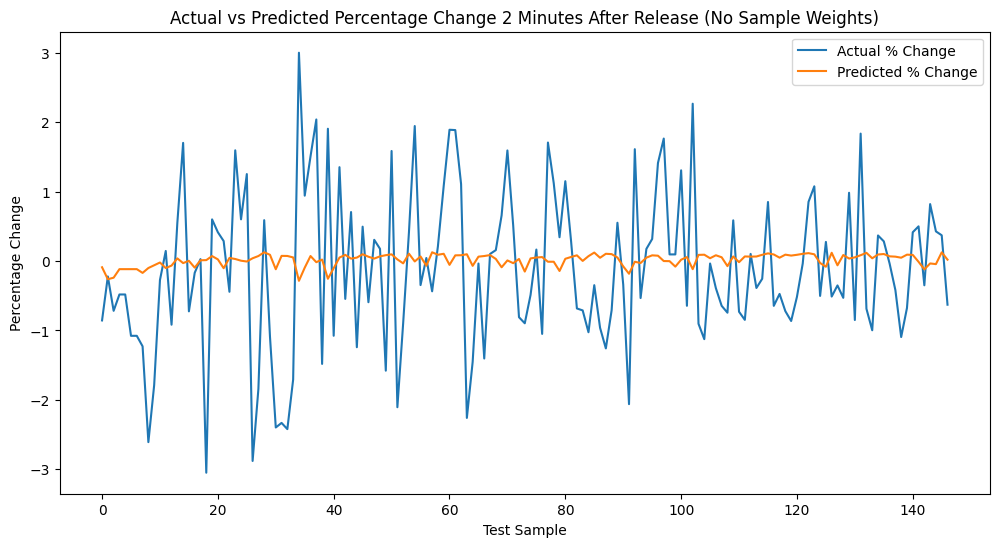

```python
%run terenceTrainWlessModel.py
```

We look at feature importance of the model with sample weights (the one that outperforms baseline model). Check terenceTrainModel functions that uses gradient to look at feature importance using TensorFlow.

```
Feature Importance (based on gradients):
Close_t-60: 0.090692
Close_t-40: 0.065488
Close_t-20: 0.128366
Open_t0: 0.072718
Weekly Production: 0.154051
Weekly Net Import: 0.105313
Actual: 0.109036
```

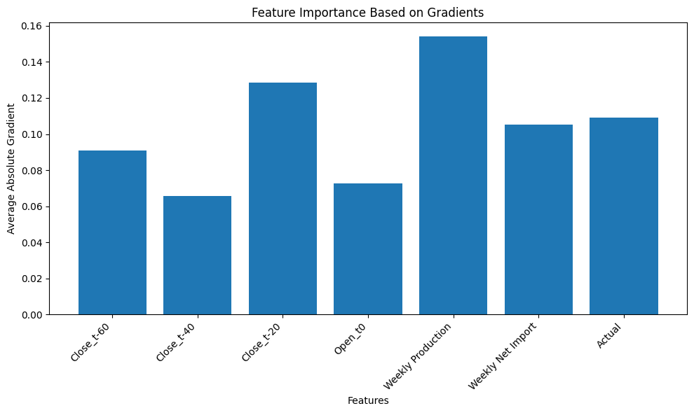

```python
from terenceTrainModel import compute_feature_importance, plot_feature_importance

feature_names = ['Close_t-60', 'Close_t-40', 'Close_t-20', 'Open_t0',
                    'Weekly Production', 'Weekly Net Import', 'Actual']
feature_importance = compute_feature_importance(trained_model, X_test)

# Print feature importance
print("\nFeature Importance (based on gradients):")
for name, importance in zip(feature_names, feature_importance):
    print(f"{name}: {importance:.6f}")

# Plot feature importance
plot_feature_importance(feature_importance, feature_names)
```

Of the future prices: t-20 and t-60 have the biggest importance in predicting the price two minutes after report release.

Across the 7 features, all are important, none are drastically insignificant.

## KNN (Samyak Kapoor)

For this project, I selected the K-Nearest Neighbors (KNN) algorithm as one of the predictive models. KNN is a non-parametric, instance-based learning method that is particularly well-suited to my core hypothesis: that the market's reaction to a new EIA report will be similar to its reaction during past events that shared similar characteristics.

Instead of trying to find a global mathematical function mapping features to an outcome, KNN operates on a simple and intuitive principle of "similarity." It classifies a new event by identifying the k most similar events (the "nearest neighbors") from the historical training data and taking a majority vote of their outcomes. This approach is powerful because it makes no assumptions about the linearity or distribution of the financial data, which is notoriously complex and non-stationary. My goal is to see if this direct, similarity-based approach can identify recurring patterns in the pre-report market dynamics and fundamental surprises to predict the subsequent price movement.

Prediction Target: The objective of this model is to predict the short-term directional movement of WTI crude oil futures in the immediate aftermath of the EIA report. I have framed this as a binary classification task.

Target Calculation: The target variable is derived from the percentage price change between the opening price of the release minute (Open_t0) and the closing price two minutes later (Close_t2).

Percentage Change = (Close_t2 - Open_t0) / Open_t0

Class Binarization: This continuous percentage change is then converted into two discrete classes, representing a simple "up" or "down" trading decision: Class 1 (UP): Assigned if the Percentage Change is positive (> 0). Class 0 (DOWN): Assigned if the Percentage Change is zero or negative (<= 0).

Crucially, in adherence with a realistic trading scenario, the model is built under the constraint that it cannot use any market information after the release (t0) except for Open_t0, which is required to establish the entry point for my hypothetical trade. All predictive features are generated from data available at or before t-1.

```python
import pandas as pd
import numpy as np
import re

master_df = pd.read_csv("full_data.csv", index_col=1, parse_dates=True)
master_df.columns = master_df.columns.str.strip()

# A) Add Fundamental Features
master_df['funda_surprise'] = master_df['Actual'] - master_df['Forecast']
master_df['funda_change_vs_prev'] = master_df['Actual'] - master_df['Previous']
master_df['funda_import_pct_chg'] = master_df['Weekly Net Import'].pct_change()
master_df['funda_prod_pct_chg'] = master_df['Weekly Production'].pct_change()

# B) Add Market Features
market_feature_names = [
    'mkt_ret_5m', 'mkt_ret_15m', 'mkt_ret_30m', 'mkt_ret_60m',
    'mkt_vol_15m', 'mkt_vol_60m', 'mkt_vol_trend_10m_60m',
    'mkt_bar_body_size', 'mkt_bar_upper_wick'
]

for index, event_row in master_df.iterrows():
    ts_df = pd.DataFrame(columns=['Open', 'High', 'Low', 'Close', 'Volume'])
    for t in range(-60, 0):
        ts_df.loc[t] = [event_row.get(f'Open_t{t}'), event_row.get(f'High_t{t}'),
                        event_row.get(f'Low_t{t}'), event_row.get(f'Close_t{t}'),
                        event_row.get(f'Volume_t{t}')]

    if ts_df.isnull().values.any(): continue
    price_anchor = ts_df.loc[-1, 'Close']; volume_anchor = ts_df['Volume'].mean()
    if pd.isna(price_anchor) or price_anchor == 0 or pd.isna(volume_anchor) or volume_anchor == 0: continue

    norm_ts_df = ts_df.copy()
    norm_ts_df[['Open','High','Low','Close']] = (ts_df[['Open','High','Low','Close']] / price_anchor) - 1
    norm_ts_df['Volume'] = ts_df['Volume'] / volume_anchor
    norm_ts_df['min_ret'] = norm_ts_df['Close'].diff()

    master_df.loc[index, 'mkt_ret_5m'] = norm_ts_df.loc[-1,'Close'] - norm_ts_df.loc[-5,'Close']
    master_df.loc[index, 'mkt_ret_15m'] = norm_ts_df.loc[-1,'Close'] - norm_ts_df.loc[-15,'Close']
    master_df.loc[index, 'mkt_ret_30m'] = norm_ts_df.loc[-1,'Close'] - norm_ts_df.loc[-30,'Close']
    master_df.loc[index, 'mkt_ret_60m'] = norm_ts_df.loc[-1,'Close'] - norm_ts_df.loc[-60,'Close']
    master_df.loc[index, 'mkt_vol_15m'] = norm_ts_df['min_ret'].iloc[-15:].std()
    master_df.loc[index, 'mkt_vol_60m'] = norm_ts_df['min_ret'].iloc[-60:].std()
    master_df.loc[index, 'mkt_vol_trend_10m_60m'] = norm_ts_df['Volume'].iloc[-10:].mean() / norm_ts_df['Volume'].mean()
    last_bar=norm_ts_df.loc[-1]
    master_df.loc[index, 'mkt_bar_body_size'] = abs(last_bar['Close']-last_bar['Open'])
    master_df.loc[index, 'mkt_bar_upper_wick'] = last_bar['High']-max(last_bar['Open'],last_bar['Close'])

all_feature_names = [
    'funda_surprise', 'funda_change_vs_prev', 'funda_import_pct_chg', 'funda_prod_pct_chg'
] + market_feature_names

final_df = master_df.dropna(subset=all_feature_names + ['Close_t2', 'Open_t0'])

X = final_df[all_feature_names]
y_raw = (final_df['Close_t2'] - final_df['Open_t0']) / final_df['Open_t0']
y = (y_raw > 0).astype(int)
```

This code performs the complete data preparation and feature engineering pipeline necessary to transform the raw dataset into a format suitable for my KNN model. I began by loading the consolidated data file and setting the report's Release Date as a time-series index. I then systematically enriched the dataset by creating thirteen high-level, predictive features.

Four of these features are fundamental, designed to quantify the economic surprise of the EIA report. This includes the critical funda_surprise feature (the difference between actual and forecasted supply) as well as normalized week-over-week changes in production and net imports.

The remaining nine features capture the market dynamics in the hour preceding the report. To generate these, I reshaped each event's flat price history into a temporary time-series and normalized it to remove biases from absolute price levels, and then calculates metrics summarizing market momentum, volatility, and volume trends. After all features were generated, I cleaned the entire dataset by removing any event with incomplete data, resulting in the final, aligned feature matrix X and target vector y used for model training.

```python
import pandas as pd
import numpy as np
import random
from sklearn.model_selection import train_test_split, TimeSeriesSplit, cross_val_score
from sklearn.preprocessing import StandardScaler
from sklearn.neighbors import KNeighborsClassifier
from sklearn.metrics import accuracy_score, classification_report, confusion_matrix, roc_auc_score


# 1. Chronological Data Split
split_point = int(len(X) * 0.80)
X_train, X_test = X.iloc[:split_point], X.iloc[split_point:]
y_train, y_test = y.iloc[:split_point], y.iloc[split_point:]


# 2. Data Scaling
scaler = StandardScaler()
X_train_scaled = scaler.fit_transform(X_train)
X_test_scaled = scaler.transform(X_test)

# 3. Hyperparameter Tuning
k_values = range(1,10)
tscv = TimeSeriesSplit(n_splits=3)
cv_scores = []

for k in k_values:
    knn = KNeighborsClassifier(n_neighbors=k)
    scores = cross_val_score(knn, X_train_scaled, y_train, cv=tscv, scoring='roc_auc')
    cv_scores.append(scores.mean())
best_k = k_values[np.argmax(cv_scores)]
print(f"Optimal 'k' found: {best_k} with average CV ROC AUC of {max(cv_scores):.4f}")
print("\n")


# --- 4. Final Model Training and Evaluation ---
final_knn = KNeighborsClassifier(n_neighbors=best_k)
final_knn.fit(X_train_scaled, y_train)
y_pred = final_knn.predict(X_test_scaled)
y_pred_proba = final_knn.predict_proba(X_test_scaled)[:, 1]
accuracy = accuracy_score(y_test, y_pred)
roc_auc = roc_auc_score(y_test, y_pred_proba)

print(f"Model: KNN with k={best_k}")
print(f"Out-of-Sample Accuracy: {accuracy:.4f}")
print(f"Out-of-Sample ROC AUC Score: {roc_auc:.4f}")

print("Confusion Matrix:")
print(pd.DataFrame(confusion_matrix(y_test, y_pred),
                 index=['Actual DOWN', 'Actual UP'],
                 columns=['Predicted DOWN', 'Predicted UP']))
print("\n")

print("Classification Report:")
print(classification_report(y_test, y_pred, target_names=['DOWN', 'UP']))
```

```
Optimal 'k' found: 5 with average CV ROC AUC of 0.5638


Model: KNN with k=5
Out-of-Sample Accuracy: 0.4694
Out-of-Sample ROC AUC Score: 0.4877
Confusion Matrix:
             Predicted DOWN  Predicted UP
Actual DOWN              26            55
Actual UP                23            43


Classification Report:
              precision    recall  f1-score   support

        DOWN       0.53      0.32      0.40        81
          UP       0.44      0.65      0.52        66

    accuracy                           0.47       147
   macro avg       0.48      0.49      0.46       147
weighted avg       0.49      0.47      0.46       147
```

To assess the predictive capability of the K-Nearest Neighbors (KNN) algorithm, I implemented a rigorous training and evaluation pipeline designed to adhere to time-series best practices and prevent look-ahead bias.

I began by partitioning the dataset chronologically, using the initial 80% of events for model training and reserving the final 20% as a completely unseen hold-out test set. To ensure that features with larger numerical scales did not disproportionately influence the distance-based KNN algorithm, all predictive features were standardized. This scaling was performed by fitting a StandardScaler.